# Problem Set 2

Author

Suzy Oakes

Published

October 16, 2026

**GitHub repo:** https://github.com/SEOAKES/EC_422_PS2_Oakes

```
✖ zoo::as.Date()                 masks base::as.Date()
✖ zoo::as.Date.numeric()         masks base::as.Date.numeric()
```

## Data

The data utilized in this document are the unemployment rate, collected monthly from January 1976 to September 2026. Included in the data are the overall US unemployment rate as well as the state-level unemployment rates for California, New York, Oregon, and Texas. Data columns have been added and altered to more clearly communicate the nature of data points (“price” was turned into “unemployment_rate”, for example). An additional data column representing the change in the unemployment rate from month to month has also been added to the data.

These are the first few rows of the raw unemployment rate data.

```r
unemp_raw <- tq_get(
  c("UNRATE", "ORUR", "CAUR", "TXUR", "NYUR"),
  get  = "economic.data",
  from = "1976-01-01"
)

head(unemp_raw)
```

```
# A tibble: 6 × 3
  symbol date       price
  <chr>  <date>     <dbl>
1 UNRATE 1976-01-01   7.9
2 UNRATE 1976-02-01   7.7
3 UNRATE 1976-03-01   7.6
4 UNRATE 1976-04-01   7.7
5 UNRATE 1976-05-01   7.4
6 UNRATE 1976-06-01   7.6
```

These are the first few rows of transformed data that are a little easier to understand and include a column for the change in the unemployment rate.

```r
dir.create("data", showWarnings = FALSE)

write_rds(unemp_raw, "data/unemp_raw.rds")

unemp_raw = read_rds("data/unemp_raw.rds")

unemp <- unemp_raw |>
  rename(unemployment_rate = price) |>
  mutate(
    region = case_when(
      symbol == "UNRATE" ~ "United States",
      symbol == "ORUR" ~ "Oregon",
      symbol == "CAUR" ~ "California",
      symbol == "TXUR" ~ "Texas",
      symbol == "NYUR" ~ "New York"
    )
  )

unemp <- unemp |>
  arrange(region, date) |>
  group_by(region) |>
  mutate(
    unemployment_rate = replace(
      unemployment_rate,
      date == as.Date("2025-10-01"),
      unemployment_rate[date == as.Date("2025-09-01")]
    )
  ) |>
  ungroup()

unemp <- unemp |>
  arrange(region, date) |>
  group_by(region) |>
  mutate(unemployment_rate_change = unemployment_rate - lag(unemployment_rate)) |>
  ungroup()

head(unemp)
```

```
# A tibble: 6 × 5
  symbol date       unemployment_rate region     unemployment_rate_change
  <chr>  <date>                 <dbl> <chr>                         <dbl>
1 CAUR   1976-01-01               9.2 California                  NA
2 CAUR   1976-02-01               9.2 California                   0
3 CAUR   1976-03-01               9.1 California                  -0.1000
4 CAUR   1976-04-01               9   California                  -0.1000
5 CAUR   1976-05-01               8.9 California                  -0.1000
6 CAUR   1976-06-01               8.9 California                   0
```

## Wrangling

To get a better sense of what the data is saying on a holistic level, it’s been split into four tables. The following section includes these tables and brief descriptions of them.

The first table summarizes the mean, minimum, and maximum unemployment rates for each region in the data between 1976 and 2026.

```r
unemp_summary <-  unemp |>
  group_by(region) |>
  summarize(
    mean_rate = mean(unemployment_rate, na.rm = TRUE),
    min_rate = min(unemployment_rate, na.rm = TRUE),
    max_rate = max(unemployment_rate, na.rm = TRUE)
  )

kable(unemp_summary)
```

| region | mean_rate | min_rate | max_rate |
| --- | --- | --- | --- |
| California | 7.074342 | 3.8 | 16.1 |
| New York | 6.346546 | 3.8 | 16.7 |
| Oregon | 6.661513 | 3.4 | 13.7 |
| Texas | 5.847040 | 3.4 | 12.8 |
| United States | 6.046305 | 3.4 | 14.8 |

The second table summarizes the mean, minimum, and maximum unemployment rates for each region, but only between 2015 and 2026.

```r
unemp_recent <- unemp |>
  filter(date > "2014-12-01")

unemp_recent_summary <-  unemp_recent |>
  group_by(region) |>
  summarize(
    mean_rate = mean(unemployment_rate, na.rm = TRUE),
    min_rate = min(unemployment_rate, na.rm = TRUE),
    max_rate = max(unemployment_rate, na.rm = TRUE)
  )

kable(unemp_recent_summary)
```

| region | mean_rate | min_rate | max_rate |
| --- | --- | --- | --- |
| California | 5.631429 | 3.8 | 16.1 |
| New York | 5.100714 | 3.8 | 16.7 |
| Oregon | 4.749286 | 3.4 | 13.7 |
| Texas | 4.581429 | 3.4 | 12.8 |
| United States | 4.619858 | 3.4 | 14.8 |

The third table contains the top five **increases** in the unemployment rate from month to month for each region, including the date and unemployment rate corresponding to each top increase. This table does not include any data points from 2020.

```r
unemp_top_increases <- unemp |>
  group_by(region) |>
  slice_max(unemployment_rate_change, n = 5) |>
  arrange(region, desc(unemployment_rate_change)) |>
  ungroup()

unemp_no_covid <- unemp |>
  filter_out(c(date >= "2020-01-01" & date <= "2020-12-01"))

unemp_top_increases_no_covid <- unemp_no_covid |>
  group_by(region) |>
  slice_max(unemployment_rate_change, n = 5) |>
  arrange(region, desc(unemployment_rate_change)) |>
  ungroup()

kable(unemp_top_increases_no_covid)
```

| symbol | date | unemployment_rate | region | unemployment_rate_change |
| --- | --- | --- | --- | --- |
| CAUR | 2009-01-01 | 9.9 | California | 0.6 |
| CAUR | 2008-11-01 | 8.8 | California | 0.5 |
| CAUR | 2008-12-01 | 9.3 | California | 0.5 |
| CAUR | 2009-02-01 | 10.4 | California | 0.5 |
| CAUR | 2008-10-01 | 8.3 | California | 0.4 |
| CAUR | 2009-03-01 | 10.8 | California | 0.4 |
| NYUR | 2008-12-01 | 6.7 | New York | 0.4 |
| NYUR | 2009-02-01 | 7.5 | New York | 0.4 |
| NYUR | 2009-03-01 | 7.9 | New York | 0.4 |
| NYUR | 2009-01-01 | 7.1 | New York | 0.4 |
| NYUR | 1992-01-01 | 8.3 | New York | 0.3 |
| ORUR | 2008-12-01 | 8.9 | Oregon | 0.7 |
| ORUR | 2008-11-01 | 8.2 | Oregon | 0.7 |
| ORUR | 2009-01-01 | 9.6 | Oregon | 0.7 |
| ORUR | 1980-03-01 | 7.4 | Oregon | 0.6 |
| ORUR | 1980-04-01 | 8.0 | Oregon | 0.6 |
| ORUR | 1980-05-01 | 8.6 | Oregon | 0.6 |
| ORUR | 2009-02-01 | 10.2 | Oregon | 0.6 |
| TXUR | 2009-05-01 | 7.6 | Texas | 1.1 |
| TXUR | 2009-06-01 | 8.1 | Texas | 0.5 |
| TXUR | 1982-12-01 | 8.3 | Texas | 0.3 |
| TXUR | 1986-03-01 | 8.3 | Texas | 0.3 |
| TXUR | 2008-12-01 | 5.9 | Texas | 0.3 |
| UNRATE | 1980-04-01 | 6.9 | United States | 0.6 |
| UNRATE | 1980-05-01 | 7.5 | United States | 0.6 |
| UNRATE | 2009-02-01 | 8.3 | United States | 0.5 |
| UNRATE | 1986-02-01 | 7.2 | United States | 0.5 |
| UNRATE | 2008-12-01 | 7.3 | United States | 0.5 |
| UNRATE | 2009-01-01 | 7.8 | United States | 0.5 |

The final table contains the top five **decreases** in the unemployment rate from month to month for each region, including the date and unemployment rate corresponding to each top increase. This table does not include any data points from 2020.

```r
unemp_top_decreases <- unemp |>
  group_by(region) |>
  slice_min(unemployment_rate_change, n = 5) |>
  arrange(region, desc(unemployment_rate_change)) |>
  ungroup()

unemp_top_decreases_no_covid <- unemp_no_covid |>
  group_by(region) |>
  slice_min(unemployment_rate_change, n = 5) |>
  arrange(region, desc(unemployment_rate_change)) |>
  ungroup()

kable(unemp_top_decreases_no_covid)
```

| symbol | date | unemployment_rate | region | unemployment_rate_change |
| --- | --- | --- | --- | --- |
| CAUR | 2021-05-01 | 8.0 | California | -0.4 |
| CAUR | 2021-08-01 | 7.0 | California | -0.4 |
| CAUR | 2021-10-01 | 6.1 | California | -0.4 |
| CAUR | 2022-02-01 | 4.8 | California | -0.4 |
| CAUR | 2021-07-01 | 7.4 | California | -0.5 |
| CAUR | 2021-09-01 | 6.5 | California | -0.5 |
| NYUR | 2021-05-01 | 7.5 | New York | -0.4 |
| NYUR | 2021-11-01 | 5.5 | New York | -0.4 |
| NYUR | 2022-02-01 | 4.8 | New York | -0.4 |
| NYUR | 2021-07-01 | 7.0 | New York | -0.5 |
| NYUR | 2021-09-01 | 6.2 | New York | -0.6 |
| ORUR | 1977-07-01 | 7.1 | Oregon | -0.3 |
| ORUR | 1983-11-01 | 10.1 | Oregon | -0.3 |
| ORUR | 1986-07-01 | 8.1 | Oregon | -0.3 |
| ORUR | 2021-05-01 | 5.6 | Oregon | -0.3 |
| ORUR | 1977-06-01 | 7.4 | Oregon | -0.4 |
| ORUR | 1977-03-01 | 8.6 | Oregon | -0.4 |
| ORUR | 2021-07-01 | 5.0 | Oregon | -0.4 |
| ORUR | 1977-05-01 | 7.8 | Oregon | -0.5 |
| TXUR | 1984-01-01 | 6.8 | Texas | -0.3 |
| TXUR | 1984-03-01 | 6.3 | Texas | -0.3 |
| TXUR | 1984-05-01 | 5.9 | Texas | -0.3 |
| TXUR | 2011-10-01 | 7.8 | Texas | -0.3 |
| TXUR | 2011-11-01 | 7.5 | Texas | -0.3 |
| TXUR | 2012-03-01 | 6.7 | Texas | -0.3 |
| TXUR | 2021-08-01 | 5.3 | Texas | -0.3 |
| TXUR | 2021-09-01 | 5.0 | Texas | -0.3 |
| TXUR | 1983-10-01 | 7.6 | Texas | -0.3 |
| TXUR | 1983-12-01 | 7.1 | Texas | -0.3 |
| UNRATE | 1983-01-01 | 10.4 | United States | -0.4 |
| UNRATE | 1996-08-01 | 5.1 | United States | -0.4 |
| UNRATE | 1998-04-01 | 4.3 | United States | -0.4 |
| UNRATE | 2021-11-01 | 4.1 | United States | -0.4 |
| UNRATE | 2010-12-01 | 9.3 | United States | -0.5 |
| UNRATE | 2014-04-01 | 6.2 | United States | -0.5 |
| UNRATE | 2021-07-01 | 5.4 | United States | -0.5 |
| UNRATE | 1983-07-01 | 9.4 | United States | -0.7 |

## Visualization

In order to visualize the data effectively, four graphs were created to represent the data. The following section includes these graphs and brief descriptions of them.

**Line plot**

The first graph is a line plot of the unemployment rate from 1976-2026, sectioned out by region.

[figure not shown]

```r
ggplot(unemp, aes(x = date, y = unemployment_rate, color = region)) +
  geom_line() +
  labs(title = "Unemployment Rate by US Region, 1976-2026",
       x = "Unemployment Rate",
       y = "Date") +
  theme_minimal()
```

**Regionally-split line plot**

The second graph pulls from the same data as the first graph, but each line of data that represents the data of a particular region is placed into its own graph.

Due to the squishing of all these graphs in a smaller space, the date ranges for each graph have disappeared or become difficult to read. The date ranges remain the same as the first graph: monthly data points from 1976 to 2026.

[figure not shown]

```r
ggplot(unemp, aes(x = date, y = unemployment_rate, color = region)) +
  geom_line() +
  labs(title = "Unemployment Rate by US Region, 1976-2026",
       x = "Unemployment Rate",
       y = "Date") +
  facet_wrap(~region) +
  theme_minimal()
```

**Bar chart**

The third graph is a bar chart pulling data from the unemployment summary table. In particular, the bar graph is ordering, from lowest to highest, the mean unemployment rate by region between 1976 and 2026.

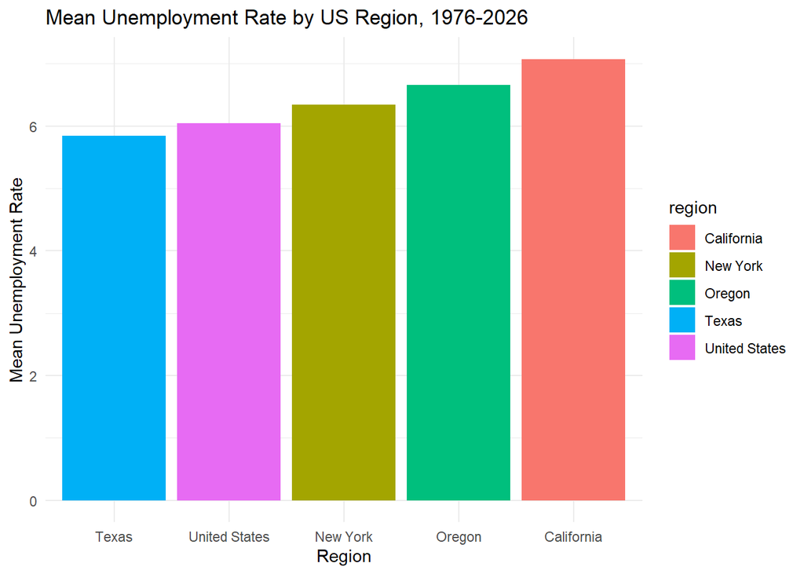

```r
ggplot(unemp_summary, aes(x = fct_reorder(region, mean_rate), y = mean_rate,
                          fill = region))  +
  geom_col() +
  labs(title = "Mean Unemployment Rate by US Region, 1976-2026",
       x = "Region",
       y = "Mean Unemployment Rate") +
  theme_minimal()
```

**Something I find interesting in the data: a line plot of the unemployment rate without 2020**

For my own choice of data to plot, I decided to make a line plot of the unemployment rate by region, excluding the year 2020. I was curious as to how this line plot might differ from the first line plot; I wanted to see visually what an unemployment rate without COVID might have looked like. Of course, shocks to the unemployment rate continued even after 2020, but excluding that year, it is striking how much the data changes.

[figure not shown]

```r
ggplot(unemp_no_covid, aes(x = date, y = unemployment_rate, color = region)) +
  geom_line() +
  labs(title = "Unemployment Rate by US Region, 1976-2026 (excluding 2020)",
       x = "Unemployment Rate",
       y = "Date") +
  theme_minimal()
```

## Reflection

This problem set was very instructive regarding basic data cleaning, wrangling, and visualization techniques. It was rather straight-forward and easy to follow for the most part, which I was glad for, but as if I were a child being thrown into a pool in order to teach me how to swim, certain sections that only said something to the effect of “use this command to do this” or just “do this” without explicit code instructions naturally made me stumble. For example, it took me a little bit to figure out where `fct_reorder` was supposed to go in the code for `ggplot` in order to actually get it to work.

This is not unexpected nor unwelcome. It is these challenges that allow one to *actually* learn and not just copy all of someone else’s code. Now, after having completed this problem set, I can say that I feel a lot more comfortable figuring things out when I get stuck. More and more, I’m feeling like I’m beginning to understand R. I also appreciated the introduction to Quarto! I feel a lot better about making a smooth, easy-to-understand document to display results from R. Before, I had only used R Markdown!